# debian12custom-RUS

[figure not shown]

[www.debian.org](https://www.debian.org/)

## Вариант моих настроек Linux Debian 12.1 "Bookworm" Xfce +

### **Введение**

В этой статье я хотел бы поделиться своим личным опытом использования операционной системы Debian 12.1 "Bookworm" с рабочим пространством Xfce. Я расскажу о своих впечатлениях и причинах, по которым я выбрал данную конфигурацию. Debian 12 "Bookworm" - это новая стабильная версия Debian, которая была выпущена после долгого периода разработки. Xfce - это легковесное и быстрое рабочее пространство, которое является одним из вариантов по умолчанию в Debian. Давайте рассмотрим подробности этой конфигурации и преимущества, которые она предлагает.

## **Debian 12 "Bookworm"**

**Debian 12 "Bookworm"** - это новая стабильная версия **Debian**, которая была выпущена после длительного периода разработки. Она предлагает множество новых функций, улучшений и обновлений, делая Debian еще более мощным и удобным для использования.

[figure not shown]

### Главные новые функции в Debian 12 "Bookworm"

- **Обновленное ядро**

  Debian 12 "Bookworm" поставляется с обновленным ядром Linux 6.1, что обеспечивает более высокую производительность и поддержку нового аппаратного обеспечения.
- **Улучшенная поддержка Secure Boot**

  В новой версии Debian 12 "Bookworm" была восстановлена поддержка Secure Boot на ARM64, что позволяет пользователям использовать эту функцию безопасности на поддерживаемом оборудовании.
- **Новые версии программного обеспечения**

  Debian 12 "Bookworm" включает в себя обновленные версии различного программного обеспечения, включая Apache 2.4.57, GIMP 2.10.34, LibreOffice 7.4 и многие другие. Обновленное программное обеспечение обеспечивает улучшенную функциональность и исправление ошибок.
- **Улучшенная поддержка языков**

  Debian 12 "Bookworm" предлагает больше переведенных страниц справки на разных языках, что делает его более доступным для пользователей по всему миру.

## **Рабочее пространство Xfce 4.18**

[www.xfce.org](https://www.xfce.org/)

**Xfce** - это быстрое и легковесное рабочее пространство, которое предоставляет пользователю удобную и гибкую среду для работы с операционной системой. Оно является одним из наиболее популярных рабочих пространств в Linux-сообществе и широко используется в различных дистрибутивах, включая Debian. Xfce предлагает простой и интуитивно понятный интерфейс, который позволяет пользователям настраивать и адаптировать свою рабочую среду под свои потребности.

**Преимущества Xfce:**

- *Легковесность.*

  Xfce потребляет меньше системных ресурсов по сравнению с другими рабочими пространствами, что делает его идеальным выбором для старых и медленных компьютеров. Оно обеспечивает быструю и отзывчивую работу даже на устройствах с ограниченными ресурсами.
- *Гибкость*.

  Xfce предлагает широкий спектр настроек и возможностей для персонализации рабочего пространства. Пользователи могут настроить панели задач, меню, горячие клавиши и темы оформления по своему вкусу.
- *Стабильность*.

  Xfce известно своей надежностью и стабильностью. Оно предлагает плавную и непрерывную работу, что особенно важно для профессионалов, которым требуется стабильная среда для работы.

**Новые функции в Xfce 4.18**

В **Xfce 4.18** представлено несколько новых функций и улучшений для рабочего пространства.

- Релиз 4.18 включает новый виджет ввода файлов и редактор ярлыков.
- Сервис **tumbler** имеет улучшения производительности и теперь поддерживает общие репозитории миниатюр.
- Панель включает новый плагин часов с различными вариантами расположения.
- Менеджер **xfdesktop** позволяет пользователям скрывать опцию "Удалить" в контекстном меню и добавляет запрос на подтверждение для перестановки значков на рабочем столе.
- Менеджер настроек **xfce4-settings** имеет упрощенную строку поиска и улучшения в настройках отображения и внешнего вида.
- **Thunar** - файловый менеджер, имеет новые функции, такие как отображение количества файлов в каталоге и даты создания файлов, а также два новых режима предварительного просмотра для изображений.
- Также добавлена возможность отменить и повторить операции с файлами и выделять файлы разными цветами.
- Панель инструментов теперь может быть настроена по желанию.

## Моя конфигурация Debian 12 "Bookworm" с Xfce

**Debian 12 "Bookworm" с Xfce**

Я выбрал **Debian 12 "Bookworm"** с рабочим пространством Xfce для своей конфигурации, потому что это сочетание предлагает мне оптимальное сочетание производительности и функциональности. Xfce обеспечивает мне легкость использования и гибкость настройки рабочего пространства, а Debian 12 "Bookworm" предоставляет мне стабильность и широкий выбор программного обеспечения.

**Процесс установки**

Установка Debian 12 "Bookworm" с рабочим пространством Xfce была простой и интуитивно понятной. Я загрузил установочный образ Debian 12 "Bookworm" с официального сайта Debian и записал его на USB-накопитель. Затем я перезагрузил свой компьютер с USB-накопителя и следовал инструкциям установщика.

Во время установки я выбрал рабочее пространство Xfce в качестве предпочтительного варианта. Установщик предложил мне выбрать компоненты и настройки системы, и я выбрал те, которые соответствуют моим потребностям. После завершения установки я перезагрузил компьютер и вошел в свою новую систему.

### Пример настроек после сетевой установки Debian 12 в минимальном объеме с активной учетной записью root (без sudo):

#### 1. Заменить репозитории в **sources.list**

Редактируем командами:

```
~$ su
```

**Password:** ввод пароля root

В открывшемся каталоге с правами root редактируем `sources.list` в nano, vim или любом текстовом редакторе:

```
~$  nano /etc/apt/sources.list
```

- Закоментируем следующую строку и сохраним файл с изменениями:

[output not shown]

- При желании можо из файла удалить всё, вставив только следующие репозитории:

> **Официальные репозитории:**

Cтандартное содержимое конфигурационного файла **sources.list** :

[output not shown]

Мы должны заменять список репозиториев в нашей системе лишь тогда, когда это действительно необходимо, в тех случаях, когда в списке репозиториев появилась некорректная информация или сам файл со списком был поврежден.

#### 2. Обновляем базу данных обновленных репозиториев.

```
~$ apt update
```

#### 3. Возможно потребуется устанавить `сut`, `nano`, `wget` (но обычно пакет уже установлен):

```
~$ apt install cut nano wget
```

#### 4. Добавление 32-битной архитектуры (для 64-битных систем):

```
~$ sudo dpkg --add-architecture i386
```

#### 5. Настраиваем **sudo** для себя как **root**:

- откываем файл `sudoers`

```
~$ nano /etc/sudoers
```

- добавляем вместо `'user'` ваше имя пользователя:

```
# User privilege specification
 root    ALL=(ALL:ALL) ALL
'user' ALL=(ALL:ALL) ALL
```

- переходим в каталог `lightdm.conf.d`

```
~$ cd /usr/share/lightdm/lightdm.conf.d
```

- откываем файл `01_debian.conf`

```
 ~$ nano 01_debian.conf
```

- изменяем в нем `true` на `false`:

```
[Seat:*]
greeter-session=lightdm-greeter
greeter-hide-users=false
session-wrapper=/etc/X11/Xsession
```

- далее после сохранения устанавливаем инструмент для настройки и управления внешним видом и поведением LightDM GTK+ Greeter, который является графическим интерфейсом для входа в систему LightDM командой:

```
~$ apt install lightdm-gtk-greeter-settings
```

#### 6. Настраиваем **автоматический вход** при запуске системы.

Для этого необходимо отредактировать файл `lightdm.conf`:

```
~$ nano /etc/lightdm/lightdm.conf
```

В открывшемся для редактирования `lightdm.conf`, после параметра **[Seat:*]** находим строки:

```
#autologin-user=
#autologin-user-timeout=0
```

Нужно обе строки раскоментировать и прописать свое имя пользователя в `autologin-user= ...`, при котором запланирован автовход в систему.

Далее не забываем **сохранить** исправленный конфигурационный файл.

```
# Пример:

autologin-user=my_name
autologin-user-timeout=0
```

#### 7. Установлю пакеты для Блютуз:

```
~$ sudo apt install blueman blueman bluez pulseaudio-module-bluetooth
```

#### 8. Синхронизируем тему **GTK** c **Qt**:

```
~$  apt install qt5ct qt5-style-plugins
```

#### 9. Добавляем пользователя в группу **sudo** (активация sudo) командами:

```
~$ su -
```

```
~$ adduser имя_пользователя sudo
```

#### 10. Выполняем перезагрузку компьютера

```
~$ reboot
```

## После перезагрузки:

#### 11. Обновляю систему компьютера уже с использованием sudo и подключенной ранее 32х битной архитектуры:

```
~$ sudo apt update && sudo apt upgrade -y
```

### 12. **Установка Python3 в системе:**

Теоретически в дистрибутивах Linux можно установить несколько версий Python, но по умолчанию может быть только одна версия. Настройка Python 3.11 по умолчанию требует некоторых дополнительных шагов. Следуйте дальше.

- **Запустим** команду **ls**, чтобы узнать, какие двоичные исполняемые файлы Python доступны в вашей системе:

```
~$ ls /usr/bin/python*

 /usr/bin/python3     /usr/bin/python3.11-config

 /usr/bin/python3.11  /usr/bin/python3-config
```

- **Проверим** предустановленную версию *Python3* в нашей системе командой:

```
~$ python3 --version
```

Python 3.11.5

- Добавим репозиторий:

```
~$ sudo add-apt-repository ppa:deadsnakes/ppa
```

- **Если версия нас устраивает,то доустанавливаем полный пакет Python3 командой:**

```
~$ sudo apt install python3-full
```

- **Устанавливаем** менаджер пакетов **pip:**

```
~$ sudo apt install python3-pip
```

- **Проверяем** его установку командой:

```
~$ pip -V
```

pip 23.0.1 from /usr/lib/python3/dist-packages/pip (python 3.11)

- **Если версия предустановленного Python вас НЕ-устраивает**,

  то прежде чем сделать что-либо убедитесь, что вы знаете, какие приложения зависят от уже предустановленного в системе Python3 версии которую вы получили в результатае выполнения в терминале команды:

```
~$ python3 --version
```

`Python 3.11.5`

- Просмотрим зависимости, используя команду:

```
~$ apt-cache rdepends python3.11
```

```
    python3.11
    Reverse Depends:
      libpython3.11-testsuite
      python3-uno
      virtnbdbackup
      stimfit
      python3-stfio
      python3-skorch
      rhythmbox-plugins
      python3-torchvision
      python3-torchtext
      python3-torchaudio
      python3.11-venv
      python3.11-minimal
      python3.11-full
      python3.11-doc
      python3.11-dev
      python3.11-dbg
      python3
      idle-python3.11
      idle-python3.11
      python3-all
      cluster-glue
      python3-escript-mpi
      python3-escript
      plasma-firewall
      pitivi
      obs-studio
      liferea
      python3-sbml5
      python3-uno
      atac
      kitty
      kdevelop-python
      libglib2.0-tests
      gedit
```

- **Устанавливаем** новую версию python 3.12:

```
~$ sudo apt install python3.12-full
```

- **Добавление** Python 3.11 и 3.12 в **Update Alternatives**:

  Для добавления обоих версий Python в утилиту "update-alternatives", выполним следующие команды:

```
~$ sudo update-alternatives --install /usr/bin/python3 python3 /usr/bin/python3.11 2
~$ sudo update-alternatives --install /usr/bin/python3 python3 /usr/bin/python3.12 1
```

*Здесь:*

`/usr/bin/python3` - это символическая ссылка на текущую версию Python 3.

`/usr/bin/python3.11` и `/usr/bin/python3.12` - это пути к установленным версиям Python 3.11 и 3.12 соответственно.

`1` и `2` - это приоритеты, где более высокий приоритет означает более предпочтительную версию.

- **Выбор** новой версии Python по умолчанию:

Теперь, после выполнения вышеуказанных команд, получим возможность выбрать, какую версию Python 3 использовать, выполнив команду:

```
 ~$ sudo update-alternatives --config python3
```

[output not shown]

- **Проверим** успешную установку версии Python3 по умолчанию в нашей системе командой:

```
~$ python3 -V
```

Python 3.12.2

**Важно:**

*После завершения этих шагов, мы можем переключаться между **Python 3.11** и **Python 3.12** с помощью утилиты **"update-alternatives"** в зависимости от наших потребностей.*

### 13. Одной командой устанавливаю необходимые мне утилиты

```
~$ sudo apt install gdebi ntfs-3g gtkhash thunar-gtkhash nautilus fuseiso gnome-disk-utility gnome-system-tools synaptic firmware-misc-nonfree curl apt-transport-https dirmngr
   ttf-mscorefonts-installer fonts-freefont-otf fonts-freefont-ttf fonts-noto-core rar unrar libavcodec-extra
```

*Вот объяснения утилит и пакетов, перечисленных выше:*

[output not shown]

#### Как в XFCE добавить индикатор раскладки на панель ?

Если у вас после установки или по каким-то инным причинам(случайно удалили через *autoremove*) на панели отсутствует индикатор раскладки клавиатуры,то эта проблема решается нехитрым способом:

```
~$ sudo apt install xfce4-xkb-plugin
```

Затем правой кнопкой мыши кликайте на панели. Пункт "Панель" → "Добавить новые элементы", ищите пункт "Раскладки клавиатуры", выделяете его и жмете кнопку "Добавить". Появился флажок. Если хотите, кликните на флажке правой кнопкой мыши, выберите "Переместить" и переместите его куда угодно. Закрываем окно "Добавление новых элементов".

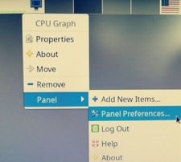

[figure not shown]

#### **xfce4-xkb-plugin** - это плагин для управления несколькими раскладками клавиатуры

Он позволяет выбрать модель клавиатуры, комбинацию клавиш для переключения между раскладками, фактические раскладки клавиатуры, способ отображения текущей раскладки (изображение флага страны или текст) и политику раскладки, которая заключается в том, сохранять ли раскладку глобально (для всех окон), для каждого приложения или для каждого окна.

1. Инсталяция плагина:

```
~$ sudo apt install xfce4-xkb-plugin
```

1. Выбор языка:

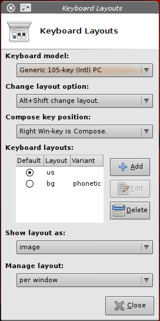

### 14. Установка заголовков и модулей ядра (kernel headers и kernel modules)

Эта установка может быть полезной, если вам нужно собирать и устанавливать дополнительные драйверы или программы, которые зависят от ядра Linux.

Если вы не планируете компилировать дополнительные модули ядра или устанавливать драйверы, не предоставляемые стандартными средствами Debian, то установка заголовков и модулей ядра может быть необязательной.

```
 ~$ sudo apt install linux-headers-$(uname -r|sed 's,[^-]*-[^-]*-,,')
```

### 15. Устанавливаю дополнительные бинарные файлы (проприетарные бинарники)

Для некоторых беспроводных адаптеров и устройств, они могут потребоваться для полной поддержки определенных аппаратных компонентов на вашем компьютере. Эти бинарные файлы включают в себя микропрограммы (firmware) для некоторых беспроводных карт и других устройств.

```
~$ sudo apt install firmware-linux-nonfree
```

### 16. Устанавливаю дополнительные инструменты для управления беспроводными сетями

Эти инструменты могут быть полезными для выполнения различных задач, связанных с настройкой и мониторингом беспроводных соединений. Например, с их помощью вы можете сканировать доступные беспроводные сети, настраивать параметры соединения, управлять беспроводными интерфейсами и многое другое.

```
~$ sudo apt install wireless-tools
```

### 17. Установлю графический интерфейс для управления сетевыми соединениями и дисками

```
~$ sudo apt install network-manager-gnome gnome-disk-utility
```

### 18. Перезагрузка!!!

```
~$ sudo reboot
```

## После перезагрузки настройка **Xfce**:

> После перезагрузки **Debian 12 "Bookworm"** с рабочим пространством **Xfce**, я настраиваю его под свои нужды.

> **Xfce** легка для системы и предлагает множество настроек и возможностей для персонализации моего рабочего пространства.

### 19. Устанавливаю утилиты Xfce, одной командой.

Каждый из этих компонентов предоставляет дополнительную функциональность и возможности настройки для среды рабочего стола Xfce, что делает ее более гибкой и удобной для пользователей.

Вы можете устанавливать или отключать их в зависимости от ваших потребностей.

```
~$ sudo apt install xfce4-battery-plugin xfce4-clipman xfce4-clipman-plugin xfce4-cpufreq-plugin xfce4-datetime-plugin xfce4-diskperf-plugin xfce4-fsguard-plugin
   xfce4-genmon-plugin xfce4-goodies xfce4-mount-plugin xfce4-sensors-plugin xfce4-smartbookmark-plugin xfce4-timer-plugin xfce4-wavelan-plugin xfce4-power-manager-plugins
```

*Приведу краткое описание каждого из перечисленных плагинов и утилит для среды рабочего стола Xfce*:

| Утилиты |  |
| --- | --- |
| xfce4-battery-plugin | Этот плагин предназначен для отображения информации о состоянии батареи ноутбука на панели. Он показывает уровень заряда, время работы от аккумулятора и другую информацию о батарее. |
| xfce4-clipman и xfce4-clipman-plugin | Эти компоненты предоставляют менеджер буфера обмена для Xfce. Они позволяют вам копировать и вставлять текст или другие данные между различными приложениями |
| xfce4-cpufreq-plugin | Этот плагин позволяет мониторить и управлять частотой процессора (CPU frequency scaling) на компьютере. Он может быть полезен для оптимизации производительности и управления энергопотреблением. |
| xfce4-datetime-plugin | Этот плагин отображает текущее время и дату на панели. Он может быть настроен на отображение различных форматов даты и времени. |
| xfce4-diskperf-plugin | Этот плагин предназначен для мониторинга производительности диска и отображает информацию о скорости чтения/записи данных на диске. |
| xfce4-fsguard-plugin | Этот плагин предоставляет мониторинг свободного места на диске и уведомляет пользователя, если свободное пространство заканчивается. |
| xfce4-genmon-plugin | Этот плагин позволяет создавать пользовательские сценарии (скрипты) и отображать результат их выполнения на панели. Он полезен для мониторинга различных системных параметров. |
| xfce4-goodies | Этот пакет включает в себя набор различных плагинов и утилит для среды Xfce, включая рассмотренные выше и другие полезные инструменты. |
| xfce4-mount-plugin | Этот плагин предоставляет быстрый доступ к средствам монтирования и отмонтирования различных устройств, таких как USB-накопители и сетевые диски. |
| xfce4-sensors-plugin | Этот плагин позволяет мониторить информацию о датчиках температуры, напряжения и других системных параметрах на вашем компьютере. |
| xfce4-smartbookmark-plugin | Этот плагин предназначен для управления закладками (bookmarks) в файловом менеджере Thunar. |
| xfce4-timer-plugin | Этот плагин позволяет устанавливать таймеры и отсчитывать время на панели. |
| xfce4-wavelan-plugin | Этот плагин предназначен для мониторинга беспроводных сетей (Wi-Fi) и отображения информации о сетях на панели. |
| xfce4-power-manager-plugins | Этот пакет включает в себя дополнительные плагины для управления энергопотреблением и настройки энергосбережения на компьютере. |

### 20. Устанавливаю утилиты для настройки и управления брандмауэром (firewall): **ufw** и **gufw**

**ufw (Uncomplicated Firewall)** - это текстовый интерфейс для настройки брандмауэра в командной строке. **ufw** упрощает управление брандмауэром, предоставляя простой способ добавления правил для разрешения или блокирования сетевого трафика.

**gufw (Graphical Uncomplicated Firewall)** - это графический интерфейс для **ufw**, который делает настройку брандмауэра более интуитивной и доступной для пользователей среды рабочего стола.

```
~$ sudo apt install ufw gufw
```

#### **Как альтернатива можете скачать мой готовый скрипт из каталога `setup-ufw.sh` и запустить его следующим образом:**

- Сохраните этот файл setup-ufw.sh на свой компьютер, затем сделайте его исполняемым с помощью команды:

  ~$ chmod +x setup-ufw.sh
- Теперь вы можете выполнить этот скрипт для настройки ufw, запустив его с правами суперпользователя:

  ~$ sudo ./setup-ufw.sh

Скрипт `setup-ufw.sh` выполнит все команды поочередно, настроит брандмауэр и включит его при каждой загрузке системы. Убедитесь, что у вас есть административные права (sudo) для выполнения этих команд.

### 21. Ставим утилиту для установки **.deb** пакетов

**GDebi** служит для установки .deb-пакетов с помощью графического интерфейса. Вы можете просто дважды щелкнуть на **.deb-файле**, и **GDebi** откроет его и предложит установить пакет, обрабатывая все зависимости автоматически.

```
~$ sudo apt install gdebi -y
```

### 22. Темы оформления и значки (иконки)

Одной из первых вещей, которую я сделал, было выбор темы оформления и значков(иконок). **Xfce** предлагает разнообразные темы оформления и значки, и я выбрал те, которые мне нравятся.

Каждый может выбрать и установить понравивщуюся ему тему и значки с ресурса www.xfce-look.org: -> [Темы](https://www.xfce-look.org/browse?cat=138&ord=latest)

**Устанавливаются все темы и иконки соответственно в папки домашней директории:**

- **~/.themes** - для темы
- **~/.icons** - для иконок

**Как альтернатива можно установить в каталогах:**

- `/usr/share/icons/` - обычно содержит предустановленные значки (общие для всех пользователей)
- `/usr/share/themes` - находятся темы оформления (общие для всех пользователей)

Теперь моя система выглядит стильно и современно.

Далее я настроил панели задач и меню. Я добавил несколько ярлыков на панель задач для быстрого доступа к моим любимым приложениям. Я также настроил меню, чтобы оно отображало только те приложения, которые я часто использую.

Далее я настроил панели задач и меню. Я добавил несколько ярлыков на панель задач для быстрого доступа к моим любимым приложениям. Я также настроил меню, чтобы оно отображало только те приложения, которые я часто использую.Я настроил горячие клавиши для быстрого запуска приложений и выполнения других часто используемых команд.

Теперь я могу легко управлять своей системой с помощью горячих клавиш.

[figure not shown]

## 23. Установка MS Visual Studio Code for Debian

- Скопируйте скрипт **install_vscode.sh** из репозитория на свой компьютер.
- Сделайте его исполняемым командой:

```
~$ chmod +x install_vscode.sh
```

- Затем выполните скрипт:

```
~$ ./install_vscode.sh
```

**Скрипт** выполнит все необходимые шаги для добавления репозитория **Visual Studio Code**, установки зависимостей и установки самого приложения на вашей системе **Debian**.

[figure not shown]

## 24. Установка из исходников!

Я всегда устанавливаю `git` из исходников, потому что в этом случае устанавливаю его последнюю версию **Git** со всеми компонентами, что делает его наиболее полным и удобным способом установки и использования Git на Debian.

**1.** Для установки всех зависимостей, используемых для предстоящей сборки и установки бинарных файлов Git необходимо:

```
~$ sudo apt-get install dh-autoreconf libcurl4-gnutls-dev libexpat1-dev \gettext libz-dev libssl-dev
```

**2.** Для того, чтобы собрать документацию в различных форматах *doc, html, info* установлю дополнительные зависимости:

```
~$ sudo apt-get install asciidoc xmlto docbook2x
```

**3.** Устанавливаю пакет *install-info*:

```
~$ sudo apt-get install install-info
```

**4.** Скачиваем последнюю версию **Git**, вы можете скачать самый свежий архив с исходниками из следующих мест:

- с сайта [Kernel.org](https://www.kernel.org/pub/software/scm/git)
- c зеркала на сайте [GitHub](https://github.com/git/git/releases)
- Затем выполните команду в терминале указав свою версию (в моем случае это *git-2.42.0.tar.xz*):

```
 ~$ wget https://mirrors.edge.kernel.org/pub/software/scm/git/git-2.42.0.tar.xz
```

**5.** Затем компилирую и устанавливаю Git, выполняя команды в следующей очередности :

```
    ~$ tar -xvf git-2.42.0.tar.xz
```

```
    ~$ cd git-2.42.0
```

```
    ~$ make configure
```

```
    ~$ ./configure --prefix=/usr
```

```
    ~$ make all doc info
```

```
    ~$ sudo make install install-doc install-html install-info
```

**6.** Проверьте установку и добавьте свои записи в кофигурационный файл Git:

```
    ~$ sudo nano ~/.gitconfig
```

Пример содержания конфигурационного файла можно посмотреть [здесь](https://gist.github.com/pksunkara/988716)

Или можно воспользоваться более простыми записями в **.gitconfig:**

```
    git config --global user.name "Simona Igls"
    git config --global user.email simona@igls.io
```

- Устанавливаю **Visual Studio Code** как редактора **Git**:

```
    git config --global core.editor "code --wait"
```

Добавлю его в свой файл **.gitignore** используя следующую запись:

```
    # Ignore VSCode Workspace Files
    *.code-workspace
```

[figure not shown]

## 25. Установка **JupyterLab Desktop**

Для моей работы я часто использую **JupyterLab Desktop**, потому что это мощное интегрированное средство разработки для анализа данных и научных вычислений. **JupyterLab** обеспечивает удобную среду для создания и выполнения блокнотов, в которых я могу комбинировать код, текст, графику и результаты вычислений в одном документе.

**JupyterLab** также предоставляет широкий выбор языков программирования, инструментов и библиотек, что делает его идеальным инструментом для работы с данными, машинным обучением и исследованиями. Он обладает гибкой настройкой и поддержкой расширений, что позволяет мне адаптировать среду разработки под свои нужды.

Я написал скрипт `install_jupyterlab_desktop.sh` для установки **JupyterLab Desktop**:

- Скопируйте скрипт `install_jupyterlab_desktop.sh` из репозитория на свой компьютер.
- Сделайте его исполняемым командой:

```
~$ chmod +x install_jupyterlab_desktop.sh
```

- Затем выполните скрипт:

```
~$ ./install_jupyterlab_desktop.sh
```

## 26. Установка дополнительных программ

Необходимые мне программы я устанавливаю блоками, эти блоки можно редактировать, удаляя, или дописывая необходимые вам программы:

```
~$ sudo apt install audacity audacious bleachbit cpufrequtils clamav clamtk evince fbreader fluid-soundfont-gm fluid-soundfont-gs gnome-mpv gpick gvidm gpicview guvcview mediainfo
   mediainfo-gui mkvtoolnix usb-modeswitch net-tools gkrellm plank
```

```
~$ sudo apt install puddletag qsynth simplescreenrecorder seahorse soundconverter timidity uget winff engrampa mpg321 vorbis-tools grub-customizer filezilla isomaster qshutdown
   gparted easytag cherrytree xfce4-screenshooter mtools kcolorchooser onboard mintstick gstreamer1.0-pulseaudio modem-manager-gui sox libsox-fmt-al
```

- Устанавливаю драйвера для принтеров:

```
~$ sudo apt-get install printer-driver-all
```

```
~$ sudo apt-get install cups hplip
```

- Установка Google Chrome:

```
    ~$ cd tmp
```

```
    ~$ sudo wget https://dl.google.com/linux/direct/google-chrome-stable_current_amd64.deb
```

```
      ~$ sudo apt install ./google-chrome-stable_current_amd64.deb
```

- Можно удалить Firefox-браузер, но это по желанию:

```
    ~$ sudo apt remove --purge xarchiver firefox-esr
    ~$ sudo apt autoremove
```

## Уменьшаю зависания выкл/вкл проблеммных процессов с 1.5 минуты на 10 секунд

- Редактирую конфигфайл с **root** правами `/etc/systemd/system.conf` :

```
   ~$ sudo nano /etc/systemd/system.conf
```

- Рекомендую раскоментировать и исправить в этих строках значения на **10s**:

```
    DefaultTimeoutStartSec=10s
    DefaultTimeoutStopSec=10s
```

# 27. **ZSH** вместо **bash**

> **Терминал Kali Linux**

> Хотя терминал **Xfce** работает xopoшо, но я предпочетаю внешний вид терминала **Kali Linux**, поэтому напишу как я это делаю.

## Установка **ZSH** на Debian

Оболочка **Z** - это оболочка Unix, которая была разработана как расширение к **BASH (Bourne shell)** в начале **90-х** годов.

**Z shell** - это интерактивная оболочка, которая включает в себя многие функции других оболочек **Unix/GNU Linux**, таких как **bash**, **fish**, **dash** и **ksh**.

1. Устанавливаю **zshell**:

```
    ~$ sudo apt update

    ~$ sudo apt install zsh
```

После установки **zsh** , запускаем команду **zsh**, чтобы переключиться с приглашения **bash** на приглашение **zsh**. Когда запустите команду, увидите приглашение настройки оболочки **Z** - выберите **0**(нулевой) вариант из предложенных в приглашении и нажмите **enter**, чтобы применить:

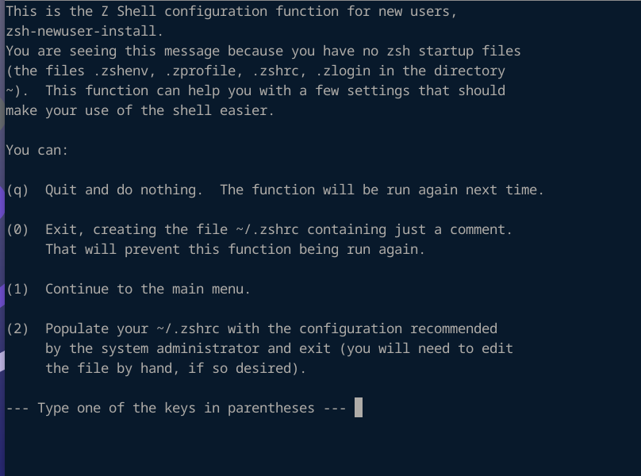

```
    ~$ zsh
```

1. Установка плагинов **zshell**

```
    ~$ sudo apt install zsh-syntax-highlighting zsh-autosuggestions
```

1. Установка **шрифтов** и **qterminal**

```
    ~$ sudo apt install qterminal fonts-firacode
`
```

1. Изменение оболочки входа по умолчанию

Воспользуюсь **chsh** - это мощный инструмент, используемый для изменения оболочки входа в систему. Нет необходимости устанавливать команду **chsh**, поскольку это стандартный пакет во всех дистрибутивах Linux.

```
    ~$ chsh -s /bin/zsh
```

- После запроса подтверждения пароля, необходимо выйти из системы, а затем снова войти, чтобы увидеть изменения.

*Приглашение **bash** будет заменено приглашением **zsh**.*

## Настройка **zshell** в **Debian**

1. Изменяем файл **.zshrc**

Файл **.zshrc** является файлом запуска, эквивалентным файлу **.bashrc** [(download)](https://github.com/Ssobol7/Debian-12-Xfce-My-Config/blob/main/zshrc) для **bash**(Bourne Again shell), который используется для настройки **zshell**.

Этот файл (~/.zshrc) является скрытым файлом и размещается в домашнем каталоге.

- Удаляю старый файл

```
    ~$ rm ~/.zshrc
```

- Создаю новый файл .zshrc

```
    ~$ touch ~/.zshrc
```

1. После успешного создания файла **.zshrc**, открою его в текстовом редакторе **nano**

```
    ~$ sudo nano ~/.zshrc
```

- и вставлю в мой **.zshrc** файл следующий скрипт:

```
# ~/.zshrc file

setopt autocd              # change directory just by typing its name
#setopt correct            # auto correct mistakes
setopt interactivecomments # allow comments in interactive mode
setopt magicequalsubst     # enable filename expansion for arguments of the form ‘anything=expression’
setopt nonomatch           # hide error message if there is no match for the pattern
setopt notify              # report the status of background jobs immediately
setopt numericglobsort     # sort filenames numerically when it makes sense
setopt promptsubst         # enable command substitution in prompt

WORDCHARS=${WORDCHARS//\/} # Don't consider certain characters part of the word

# hide EOL sign ('%')
PROMPT_EOL_MARK=""

# configure key keybindings
bindkey -e                                        # emacs key bindings
bindkey ' ' magic-space                           # do history expansion on space
bindkey '^U' backward-kill-line                   # ctrl + U
bindkey '^[[3;5~' kill-word                       # ctrl + Supr
bindkey '^[[3~' delete-char                       # delete
bindkey '^[[1;5C' forward-word                    # ctrl + ->
bindkey '^[[1;5D' backward-word                   # ctrl + <-
bindkey '^[[5~' beginning-of-buffer-or-history    # page up
bindkey '^[[6~' end-of-buffer-or-history          # page down
bindkey '^[[H' beginning-of-line                  # home
bindkey '^[[F' end-of-line                        # end
bindkey '^[[Z' undo                               # shift + tab undo last action

# enable completion features
autoload -Uz compinit
compinit -d ~/.cache/zcompdump
zstyle ':completion:*:*:*:*:*' menu select
zstyle ':completion:*' auto-description 'specify: %d'
zstyle ':completion:*' completer _expand _complete
zstyle ':completion:*' format 'Completing %d'
zstyle ':completion:*' group-name ''
zstyle ':completion:*' list-colors ''
zstyle ':completion:*' list-prompt %SAt %p: Hit TAB for more, or the character to insert%s
zstyle ':completion:*' matcher-list 'm:{a-zA-Z}={A-Za-z}'
zstyle ':completion:*' rehash true
zstyle ':completion:*' select-prompt %SScrolling active: current selection at %p%s
zstyle ':completion:*' use-compctl false
zstyle ':completion:*' verbose true
zstyle ':completion:*:kill:*' command 'ps -u $USER -o pid,%cpu,tty,cputime,cmd'

# History configurations
HISTFILE=~/.zsh_history
HISTSIZE=1000
SAVEHIST=2000
setopt hist_expire_dups_first # delete duplicates first when HISTFILE size exceeds HISTSIZE
setopt hist_ignore_dups       # ignore duplicated commands history list
setopt hist_ignore_space      # ignore commands that start with space
setopt hist_verify            # show command with history expansion to user before running it
#setopt share_history         # share command history data

# force zsh to show the complete history
alias history="history 0"

# configure `time` format
TIMEFMT=$'\nreal\t%E\nuser\t%U\nsys\t%S\ncpu\t%P'

# make less more friendly for non-text input files, see lesspipe(1)
#[ -x /usr/bin/lesspipe ] && eval "$(SHELL=/bin/sh lesspipe)"

# set variable identifying the chroot you work in (used in the prompt below)
if [ -z "${debian_chroot:-}" ] && [ -r /etc/debian_chroot ]; then
    debian_chroot=$(cat /etc/debian_chroot)
fi

# set a fancy prompt (non-color, unless we know we "want" color)
case "$TERM" in
    xterm-color|*-256color) color_prompt=yes;;
esac

# uncomment for a colored prompt, if the terminal has the capability; turned
# off by default to not distract the user: the focus in a terminal window
# should be on the output of commands, not on the prompt
force_color_prompt=yes

if [ -n "$force_color_prompt" ]; then
    if [ -x /usr/bin/tput ] && tput setaf 1 >&/dev/null; then
        # We have color support; assume it's compliant with Ecma-48
        # (ISO/IEC-6429). (Lack of such support is extremely rare, and such
        # a case would tend to support setf rather than setaf.)
        color_prompt=yes
    else
        color_prompt=
    fi
fi

configure_prompt() {
    prompt_symbol=㉿
    # Skull emoji for root terminal
    #[ "$EUID" -eq 0 ] && prompt_symbol=💀
    case "$PROMPT_ALTERNATIVE" in
        twoline)
            PROMPT=$'%F{%(#.blue.green)}┌──${debian_chroot:+($debian_chroot)─}${VIRTUAL_ENV:+($(basename $VIRTUAL_ENV))─}(%B%F{%(#.red.blue)}%n'$prompt_symbol$'%m%b%F{%(#.blue.green)})-[%B%F{reset}%(6~.%-1~/…/%4~.%5~)%b%F{%(#.blue.green)}]\n└─%B%(#.%F{red}#.%F{blue}$)%b%F{reset} '
            # Right-side prompt with exit codes and background processes
            #RPROMPT=$'%(?.. %? %F{red}%B⨯%b%F{reset})%(1j. %j %F{yellow}%B⚙%b%F{reset}.)'
            ;;
        oneline)
            PROMPT=$'${debian_chroot:+($debian_chroot)}${VIRTUAL_ENV:+($(basename $VIRTUAL_ENV))}%B%F{%(#.red.blue)}%n@%m%b%F{reset}:%B%F{%(#.blue.green)}%~%b%F{reset}%(#.#.$) '
            RPROMPT=
            ;;
        backtrack)
            PROMPT=$'${debian_chroot:+($debian_chroot)}${VIRTUAL_ENV:+($(basename $VIRTUAL_ENV))}%B%F{red}%n@%m%b%F{reset}:%B%F{blue}%~%b%F{reset}%(#.#.$) '
            RPROMPT=
            ;;
    esac
    unset prompt_symbol
}

# The following block is surrounded by two delimiters.
# These delimiters must not be modified. Thanks.
# START KALI CONFIG VARIABLES
PROMPT_ALTERNATIVE=twoline
NEWLINE_BEFORE_PROMPT=yes
# STOP KALI CONFIG VARIABLES

if [ "$color_prompt" = yes ]; then
    # override default virtualenv indicator in prompt
    VIRTUAL_ENV_DISABLE_PROMPT=1

    configure_prompt

    # enable syntax-highlighting
    if [ -f /usr/share/zsh-syntax-highlighting/zsh-syntax-highlighting.zsh ]; then
        . /usr/share/zsh-syntax-highlighting/zsh-syntax-highlighting.zsh
        ZSH_HIGHLIGHT_HIGHLIGHTERS=(main brackets pattern)
        ZSH_HIGHLIGHT_STYLES[default]=none
        ZSH_HIGHLIGHT_STYLES[unknown-token]=fg=white,underline
        ZSH_HIGHLIGHT_STYLES[reserved-word]=fg=cyan,bold
        ZSH_HIGHLIGHT_STYLES[suffix-alias]=fg=green,underline
        ZSH_HIGHLIGHT_STYLES[global-alias]=fg=green,bold
        ZSH_HIGHLIGHT_STYLES[precommand]=fg=green,underline
        ZSH_HIGHLIGHT_STYLES[commandseparator]=fg=blue,bold
        ZSH_HIGHLIGHT_STYLES[autodirectory]=fg=green,underline
        ZSH_HIGHLIGHT_STYLES[path]=bold
        ZSH_HIGHLIGHT_STYLES[path_pathseparator]=
        ZSH_HIGHLIGHT_STYLES[path_prefix_pathseparator]=
        ZSH_HIGHLIGHT_STYLES[globbing]=fg=blue,bold
        ZSH_HIGHLIGHT_STYLES[history-expansion]=fg=blue,bold
        ZSH_HIGHLIGHT_STYLES[command-substitution]=none
        ZSH_HIGHLIGHT_STYLES[command-substitution-delimiter]=fg=magenta,bold
        ZSH_HIGHLIGHT_STYLES[process-substitution]=none
        ZSH_HIGHLIGHT_STYLES[process-substitution-delimiter]=fg=magenta,bold
        ZSH_HIGHLIGHT_STYLES[single-hyphen-option]=fg=green
        ZSH_HIGHLIGHT_STYLES[double-hyphen-option]=fg=green
        ZSH_HIGHLIGHT_STYLES[back-quoted-argument]=none
        ZSH_HIGHLIGHT_STYLES[back-quoted-argument-delimiter]=fg=blue,bold
        ZSH_HIGHLIGHT_STYLES[single-quoted-argument]=fg=yellow
        ZSH_HIGHLIGHT_STYLES[double-quoted-argument]=fg=yellow
        ZSH_HIGHLIGHT_STYLES[dollar-quoted-argument]=fg=yellow
        ZSH_HIGHLIGHT_STYLES[rc-quote]=fg=magenta
        ZSH_HIGHLIGHT_STYLES[dollar-double-quoted-argument]=fg=magenta,bold
        ZSH_HIGHLIGHT_STYLES[back-double-quoted-argument]=fg=magenta,bold
        ZSH_HIGHLIGHT_STYLES[back-dollar-quoted-argument]=fg=magenta,bold
        ZSH_HIGHLIGHT_STYLES[assign]=none
        ZSH_HIGHLIGHT_STYLES[redirection]=fg=blue,bold
        ZSH_HIGHLIGHT_STYLES[comment]=fg=black,bold
        ZSH_HIGHLIGHT_STYLES[named-fd]=none
        ZSH_HIGHLIGHT_STYLES[numeric-fd]=none
        ZSH_HIGHLIGHT_STYLES[arg0]=fg=cyan
        ZSH_HIGHLIGHT_STYLES[bracket-error]=fg=red,bold
        ZSH_HIGHLIGHT_STYLES[bracket-level-1]=fg=blue,bold
        ZSH_HIGHLIGHT_STYLES[bracket-level-2]=fg=green,bold
        ZSH_HIGHLIGHT_STYLES[bracket-level-3]=fg=magenta,bold
        ZSH_HIGHLIGHT_STYLES[bracket-level-4]=fg=yellow,bold
        ZSH_HIGHLIGHT_STYLES[bracket-level-5]=fg=cyan,bold
        ZSH_HIGHLIGHT_STYLES[cursor-matchingbracket]=standout
    fi
else
    PROMPT='${debian_chroot:+($debian_chroot)}%n@%m:%~%(#.#.$) '
fi
unset color_prompt force_color_prompt

toggle_oneline_prompt(){
    if [ "$PROMPT_ALTERNATIVE" = oneline ]; then
        PROMPT_ALTERNATIVE=twoline
    else
        PROMPT_ALTERNATIVE=oneline
    fi
    configure_prompt
    zle reset-prompt
}
zle -N toggle_oneline_prompt
bindkey ^P toggle_oneline_prompt

# If this is an xterm set the title to user@host:dir
case "$TERM" in
xterm*|rxvt*|Eterm|aterm|kterm|gnome*|alacritty)
    TERM_TITLE=$'\e]0;${debian_chroot:+($debian_chroot)}${VIRTUAL_ENV:+($(basename $VIRTUAL_ENV))}%n@%m: %~\a'
    ;;
*)
    ;;
esac

precmd() {
    # Print the previously configured title
    print -Pnr -- "$TERM_TITLE"

    # Print a new line before the prompt, but only if it is not the first line
    if [ "$NEWLINE_BEFORE_PROMPT" = yes ]; then
        if [ -z "$_NEW_LINE_BEFORE_PROMPT" ]; then
            _NEW_LINE_BEFORE_PROMPT=1
        else
            print ""
        fi
    fi
}

# enable color support of ls, less and man, and also add handy aliases
if [ -x /usr/bin/dircolors ]; then
    test -r ~/.dircolors && eval "$(dircolors -b ~/.dircolors)" || eval "$(dircolors -b)"
    export LS_COLORS="$LS_COLORS:ow=30;44:" # fix ls color for folders with 777 permissions

    alias ls='ls --color=auto'
    #alias dir='dir --color=auto'
    #alias vdir='vdir --color=auto'

    alias grep='grep --color=auto'
    alias fgrep='fgrep --color=auto'
    alias egrep='egrep --color=auto'
    alias diff='diff --color=auto'
    alias ip='ip --color=auto'

    export LESS_TERMCAP_mb=$'\E[1;31m'     # begin blink
    export LESS_TERMCAP_md=$'\E[1;36m'     # begin bold
    export LESS_TERMCAP_me=$'\E[0m'        # reset bold/blink
    export LESS_TERMCAP_so=$'\E[01;33m'    # begin reverse video
    export LESS_TERMCAP_se=$'\E[0m'        # reset reverse video
    export LESS_TERMCAP_us=$'\E[1;32m'     # begin underline
    export LESS_TERMCAP_ue=$'\E[0m'        # reset underline

    # Take advantage of $LS_COLORS for completion as well
    zstyle ':completion:*' list-colors "${(s.:.)LS_COLORS}"
    zstyle ':completion:*:*:kill:*:processes' list-colors '=(#b) #([0-9]#)*=0=01;31'
fi

# some more ls aliases
alias ll='ls -l'
alias la='ls -A'
alias l='ls -CF'

# enable auto-suggestions based on the history
if [ -f /usr/share/zsh-autosuggestions/zsh-autosuggestions.zsh ]; then
    . /usr/share/zsh-autosuggestions/zsh-autosuggestions.zsh
    # change suggestion color
    ZSH_AUTOSUGGEST_HIGHLIGHT_STYLE='fg=#999'
fi

# enable command-not-found if installed
if [ -f /etc/zsh_command_not_found ]; then
    . /etc/zsh_command_not_found
fi
compinit
```

- *НЕ ЗАБЫВАЮ СОХРАНИТЬ мой .zshrc !!!*
1. Чтобы изменения вступили в силу просто закрываю и снова открываю свой терминал.

## Загрузка цветовых схем и темы Kali Linux

1. Для начала склонируем цветовые схемы и темы **Kali Linux** из репозитория **GitHub** командой:

   ```
    $ git clone https://github.com/linuxopsys/ubuntu-to-kali-terminal.git
   ```

1. После клонирования перехожу в каталог **ubuntu-to-kali-terminal** и извлекаю сжатые файлы:

```
   ~$ cd ubuntu-to-kali-terminal
   ~$ tar -xvf color-schemes.tar
   ~$ tar -xvf kali-dark-theme.tar
```

1. Удаляю каталог **qtermwidget5**, расположенный в каталоге **/usr/share**, и заменяю его каталогом из извлеченного архива tar:

```
    sudo rm -rf /usr/share/qtermwidget5
    sudo mv -f usr/share/qtermwidget5 /usr/share
```

### Изменение настроек **Qterminal**

1. Откройте настройки Qterminal: измените цветовую схему на Kali-Dark, а затем нажмите кнопку [Apply], это изменит тему терминала на Kali.
2. В нижней части настроек внешнего вида нашего терминала изменяю "Прозрачность приложения" с "0%" на "5%", так же, как в Kali, и применяю, чтобы изменения вступили в силу.

После внесения изменений ваш **qterminal** должен выглядеть следующим образом:

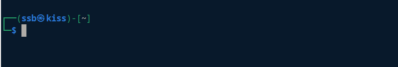

- если вам необходимо временно перейти на оболочку **bash**, а затем вернуться к оболочке **zsh** то выполните следующие команды в терминале
- для перехода:

  ```
  ~$ bash
  ```

- для возврата:

  ```
  ~$ zsh
  ```

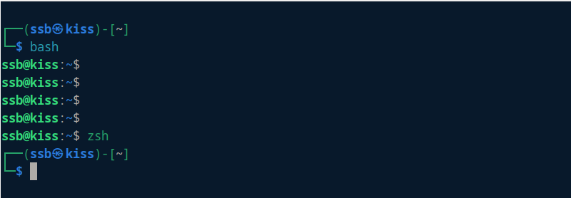

## 28. Устанавливаю обязательно пароль на **Grub**

> Для защиты моего компьютера с установленным на нем дистрибутивом Linux не лишним будет поставить пароль на доступ к загрузчику GRUB.

**Делается это в три шага:**

**1) Генерирую хэш пароль**

Это действие проделываю при поомощи утилиты **grub-mkpasswd-pbkdf2**. В Debian она по умолчанию установлена в систему. Выполняю в терминале команду:

```
~$ grub-mkpasswd-pbkdf2
```

*Получаю:*

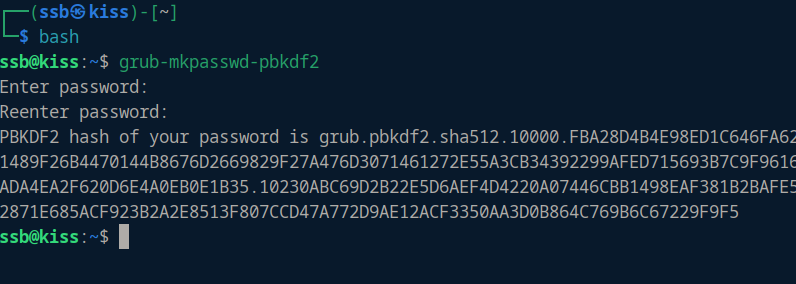

Полученный **хэш** – это длинная строка, которая начинается с **grub.pbkdf2......**

Копирую ее в текстовый редактор и сохраняю, в отдельный файл-документ на диске.

**2) Назначаю супер-пользователя для GRUB**

- Затем выполняю нстройку файла **00_header** расположенного в **/etc/grub.d/**. Открываю его в текстовом редакторе и редактирую его содержимое следующим образом.

```
~$ sudo nano /etc/grub.d/00_header
```

- И вставляю мой приготовленный заранее **скрипт** в самый конец открытого в текстовом редакторе файла **00_header** вот так:

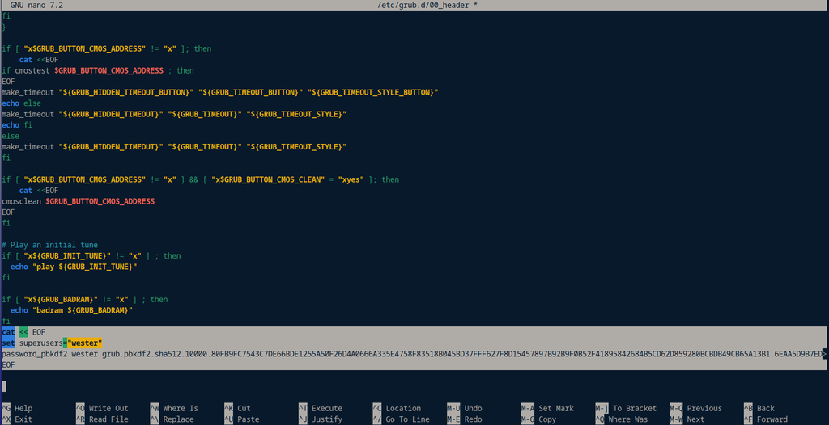

**3) Обновляю конфигурацию GRUB**

Выполняю это для применения ранее внесенных изменений при помощи команды в терминале:

```
~$ sudo update-grub
```

*Получаю:*

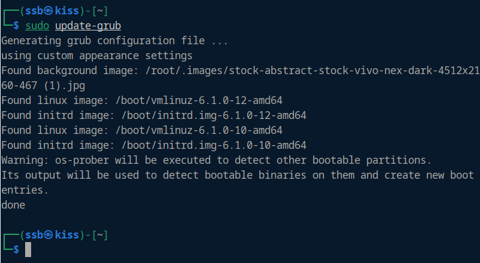

**Выполняю перезагрузку и получаю приветственный экран:**

[figure not shown]

## Заключительное слово

Моя конфигурация **Debian 12 "Bookworm"** с рабочим пространством **Xfce** предоставляет мне отличную комбинацию производительности и функциональности, но это моя личная конфигурация, обусловленная моими привычками, моими потребностями и симпатиями.

Каждый из вас может иметь свой Debian 12 "Bookworm" и свою конфигурацию.

Дайте **Debian 12 "Bookworm"** с **Xfce** шанс и вы не пожалеете о своем выборе! Буду рад принять ваши замечания и предложения!

## Authors

[Siergej Sobolewski](https://www.linkedin.com/in/siergej-s-25a16319a/)

## Change Log

| Date (YYYY-MM-DD) | Version | Changed By | Change Description |
| --- | --- | --- | --- |
| 2023-09-15 | 0.2 | Siergej | Update Lab to Git, Bash |
| 2023-09-08 | 0.1 | Siergej | Created JupyterLab |

### © 2023. All rights reserved.